# Zajęcia 8: Klastrowanie Dokumentów (K-Means)

2026-04-23

```r
# Ustawienia globalne do ukrycia ostrzeżeń w raporcie HTML
knitr::opts_chunk$set(
  message = FALSE,
  warning = FALSE
)
```

# 1 Wymagane pakiety

```r
# Wymagane pakiety ----
library(tm)           # Przetwarzanie tekstu
library(SnowballC)    # Stemming
library(cluster)      # Klastrowanie
library(wordcloud)    # Chmury słów
library(factoextra)   # Wizualizacje klastrów
library(RColorBrewer) # Kolory
library(ggplot2)      # Wykresy
library(dplyr)        # Przetwarzanie danych
library(ggrepel)      # Dodawania etykiet w wykresach
library(DT)           # Interaktywne tabele
```

# 2 Wczytanie danych tekstowych

```r
# Dane tekstowe ----
# UWAGA: Upewnij się, że masz poprawnie ustawiony Working Directory!
docs <- DirSource("textfolder")

# Utwórz korpus dokumentów tekstowych
corpus <- VCorpus(docs)
```

# 3 Przetwarzanie i oczyszczanie tekstu

W tej sekcji z tekstu usuwane są m.in. znaki interpunkcyjne, tagi HTML, cyfry oraz tzw. *stopwords* (słowa niewnoszące znaczenia). Zgodnie z wytycznymi zrezygnowano z procesu stemmingu.

```r
# 1. Przetwarzanie i oczyszczanie tekstu ----

# Zapewnienie kodowania UTF-8
corpus <- tm_map(corpus, content_transformer(function(x) iconv(x, to = "UTF-8", sub = "byte")))

# Funkcja do zamiany znaków na spację
toSpace <- content_transformer(function (x, pattern) gsub(pattern, " ", x))

# Usuwanie zbędnych znaków (URL, HTML, media społecznościowe itp.)
corpus <- tm_map(corpus, toSpace, "@")
corpus <- tm_map(corpus, toSpace, "@\\w+")
corpus <- tm_map(corpus, toSpace, "\\|")
corpus <- tm_map(corpus, toSpace, "[ \t]{2,}")
corpus <- tm_map(corpus, toSpace, "(s?)(f|ht)tp(s?)://\\S+\\b")
corpus <- tm_map(corpus, toSpace, "http\\w*")
corpus <- tm_map(corpus, toSpace, "/")
corpus <- tm_map(corpus, toSpace, "(RT|via)((?:\\b\\W*@\\w+)+)")
corpus <- tm_map(corpus, toSpace, "www")
corpus <- tm_map(corpus, toSpace, "~")
corpus <- tm_map(corpus, toSpace, "â€“")

corpus <- tm_map(corpus, content_transformer(tolower))
corpus <- tm_map(corpus, removeNumbers)
corpus <- tm_map(corpus, removeWords, stopwords("english"))
corpus <- tm_map(corpus, removePunctuation)
corpus <- tm_map(corpus, stripWhitespace)

# Usunięcie specyficznych nazw własnych
corpus <- tm_map(corpus, removeWords, c("rose", "roses", "kate", "kates", "iris", "tyler", "tylers", "javi", "javis", "reed", "josh", "joshs", "elliot", "elliots", "julian", "julians", "patrick", "patricks", "margot", "margots", "one", "however", "ladybug"))
corpus <- tm_map(corpus, stripWhitespace)

# Do dalszej analizy wykorzystany zostaje korpus bez stemmingu
final_corpus <- corpus
```

# 4 Macierz DTM i Eksploracyjna Analiza Danych (EDA)

```r
# Tokenizacja i tworzenie macierzy DTM ----
dtm <- DocumentTermMatrix(final_corpus)
dtm_m <- as.matrix(dtm)

# 2. Zliczanie częstości słów i EDA ----
v <- sort(colSums(dtm_m), decreasing = TRUE)
dtm_df <- data.frame(word = names(v), freq = v)
```

### 4.0.1 Globalna chmura słów dla całego korpusu

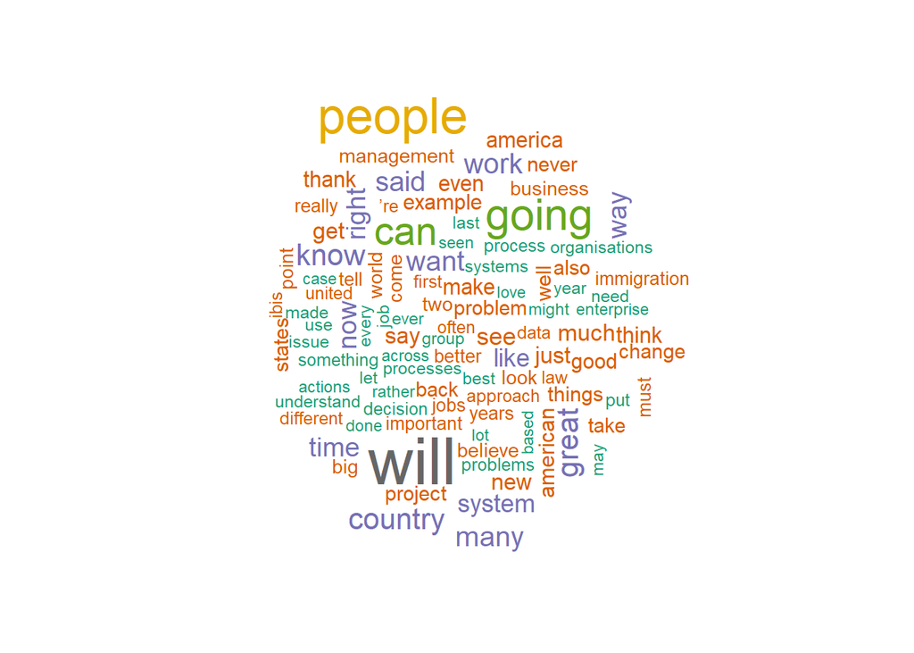

```r
# Globalna chmura słów
wordcloud(words = dtm_df$word, freq = dtm_df$freq, min.freq = 5,
          scale = c(3, 0.5), max.words = 100,
          colors = brewer.pal(8, "Dark2"))
```

# 5 Algorytm K-Means

## 5.1 Dobór liczby klastrów

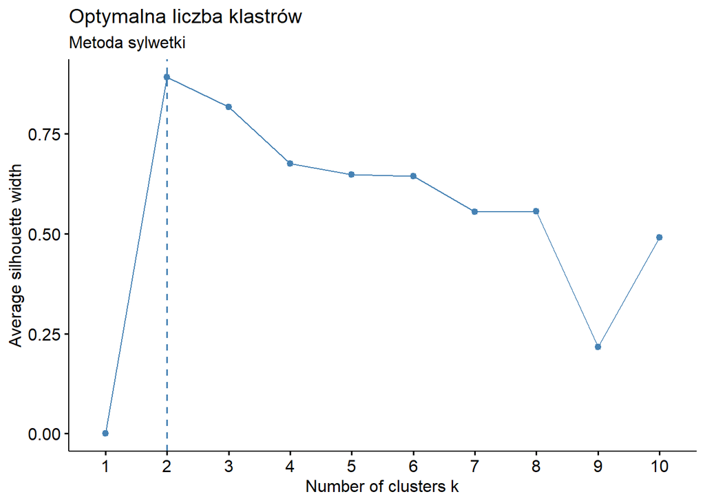

```r
# 3. Klastrowanie k-średnich (k-means) ----
set.seed(123)

# Dobór optymalnej liczby klastrów metodą sylwetki
fviz_nbclust(t(dtm_m), kmeans, method = "silhouette") +
  labs(title = "Optymalna liczba klastrów", subtitle = "Metoda sylwetki")
```

## 5.2 Wyniki klastrowania

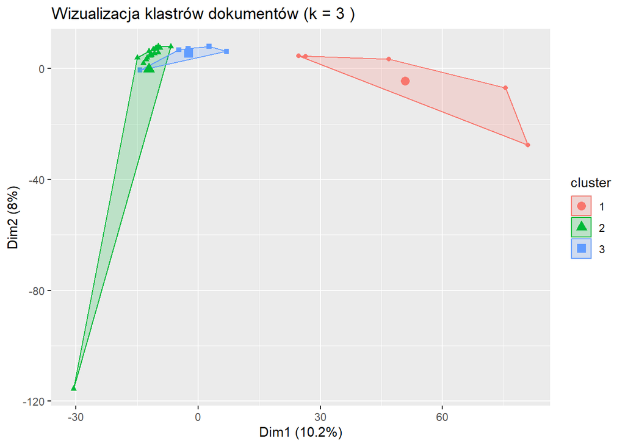

```r
# Klastrowanie dla k = 3
k <- 3
klastrowanie <- kmeans(dtm_m, centers = k)

# Wizualizacja klastrów (PCA)
fviz_cluster(list(data = dtm_m, cluster = klastrowanie$cluster),
             geom = "point",
             main = paste("Wizualizacja klastrów dokumentów (k =", k, ")"))
```

### 5.2.1 Tabela z przypisaniem plików i najpopularniejszymi słowami

```r
# Analiza klastrów - Top 5 słów
cluster_info <- lapply(1:k, function(i) {
  cluster_docs_idx <- which(klastrowanie$cluster == i)
  cluster_docs <- dtm_m[cluster_docs_idx, , drop = FALSE]
  word_freq <- sort(colSums(cluster_docs), decreasing = TRUE)
  top_words <- paste(names(word_freq)[1:5], collapse = ", ")
  data.frame(
    Klaster = i,
    Liczba_dokumentów = length(cluster_docs_idx),
    Top_5_słów = top_words,
    stringsAsFactors = FALSE
  )
})
cluster_info_df <- do.call(rbind, cluster_info)

documents_clusters <- data.frame(
  Dokument = names(final_corpus),
  Klaster = klastrowanie$cluster,
  stringsAsFactors = FALSE
)
documents_clusters_z_info <- left_join(documents_clusters, cluster_info_df, by = "Klaster")

# Interaktywna tabela
datatable(documents_clusters_z_info,
          caption = "Dokumenty, klastry, najczęstsze słowa i liczność klastrów",
          rownames = FALSE,
          options = list(pageLength = 10))
```

| Dokument | Klaster | Liczba_dokumentów | Top_5_słów |
| --- | --- | --- | --- |
| Address.txt | 1 | 5 | will, going, people, country, great |
| Apparition.txt | 2 | 20 | can, project, system, example, will |
| Architecture.txt | 2 | 20 | can, project, system, example, will |
| Big.txt | 2 | 20 | can, project, system, example, will |
| Breakfast.txt | 3 | 5 | people, will, going, know, ’re |
| Change.txt | 3 | 5 | people, will, going, know, ’re |
| Chiefs.txt | 3 | 5 | people, will, going, know, ’re |
| Design.txt | 2 | 20 | can, project, system, example, will |
| Dilemma.txt | 2 | 20 | can, project, system, example, will |
| EnterpriseIT.txt | 2 | 20 | can, project, system, example, will |

[output cut: 20 more lines]

## 5.3 Chmury słów dla poszczególnych klastrów

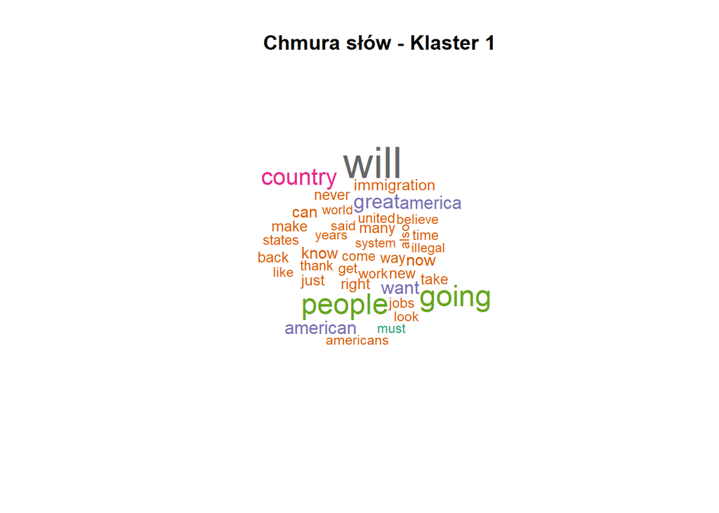

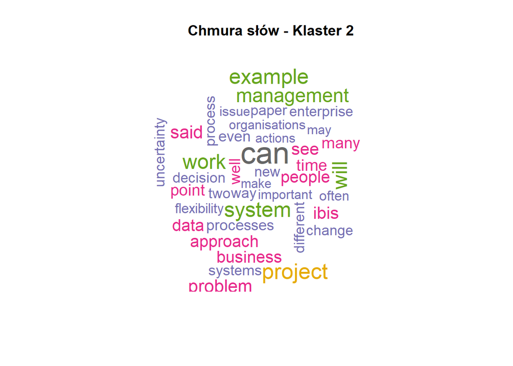

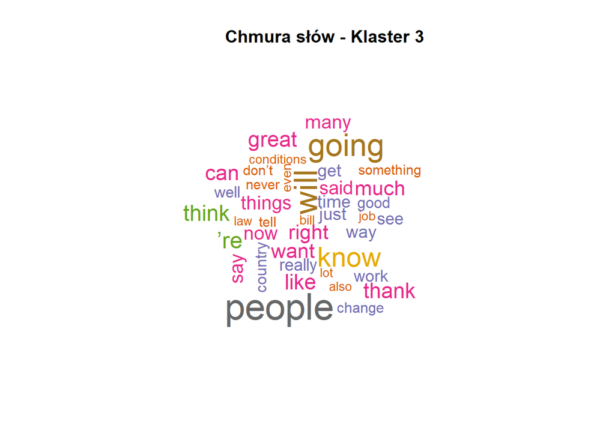

```r
# Chmury słów dla klastrów
for (i in 1:k) {
  cluster_docs_idx <- which(klastrowanie$cluster == i)
  cluster_docs <- dtm_m[cluster_docs_idx, , drop = FALSE]
  word_freq <- colSums(cluster_docs)
  wordcloud(names(word_freq), freq = word_freq,
            scale = c(2.5, 0.5), max.words = 40,
            colors = brewer.pal(8, "Dark2"))
  title(paste("Chmura słów - Klaster", i))
}
```

## 5.4 Wykres przypisania poszczególnych dokumentów

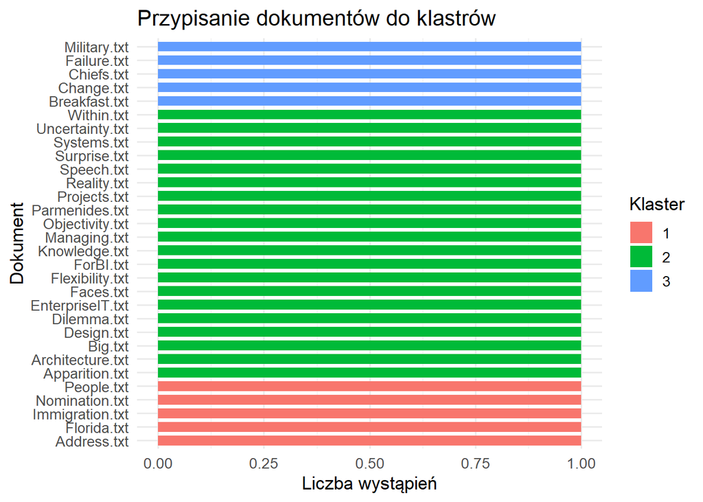

```r
# Wizualizacja przypisania do klastrów
ggplot(documents_clusters, aes(x = reorder(Dokument, Klaster), fill = as.factor(Klaster))) +
  geom_bar(stat = "count", width = 0.7) +
  coord_flip() +
  labs(title = "Przypisanie dokumentów do klastrów",
       x = "Dokument",
       y = "Liczba wystąpień",
       fill = "Klaster") +
  theme_minimal(base_size = 13)
```

# 6 Wnioski z analizy (Odpowiedzi na pytania)

**1. Czy na podstawie wyników (otrzymanych klastrów) można wnioskować o treści dokumentów?**

Tak, na podstawie uzyskanych wyników klastrowania można wnioskować o treści dokumentów. Model *Bag of Words*, wsparty chmurami słów i przypisaniem dokumentów do konkretnych grup (klastrów), pozwala bardzo szybko zidentyfikować wiodące słowa kluczowe. Dzięki temu jesteśmy w stanie wyciągnąć kontekst i główny temat poszczególnych tekstów bez konieczności czytania ich w całości.

**2. Jakich ogólnie obszarów tematycznych dotyczą klastry oraz ile jest tych obszarów?**

Wykres z metody sylwetki sugerował, że czysto matematycznie optymalny byłby podział na 2 klastry, jednak ostatecznie wyodrębniono **3 obszary tematyczne**, co pozwoliło na lepszą i bardziej szczegółową interpretację wyników. Dotyczą one następujących obszarów:

- **Klaster 1 dotyczy: Amerykańskiej polityki i spraw społecznych** (zawiera pliki np. *Immigration.txt, Florida.txt*; dominujące słowa to m.in.: country, people, american, america, immigration).
- **Klaster 2 dotyczy: Biznesu, projektów oraz branży IT / technologicznej** (zawiera pliki np. *Projects.txt, EnterpriseIT.txt*; dominujące słowa to m.in.: project, system, work, data, business, approach).
- **Klaster 3 dotyczy: Tekstów o charakterze potocznym, luźnych wypowiedzi lub transkrypcji mowy** (dominują w nim słowa charakterystyczne dla codziennej komunikacji, m.in.: think, know, say, thank, right, things).